# Project Milestone #4

Cian Stryker

10/6/2019

## Graph 1: Belt and Road Initiative Investment

My first graph is just to show how Belt and Road Initiative (BRI) funding differs per target region. BRI refers the Chinese Government’s plan to create a new Silk Road through major infastructural investments in West Asia, the Middle East, and Africa. Some theorize that South America is also a target region and the investment pattern tends to cooroberate this theory. Infastrucutral investment is typically defined by investments in Transportation, Energy, Metals, and Construction (i.e. real estate). So my graph here shows the commulative amount of Chinese FDI investment divided by BRI sector, between the four major target regions. I also animate it to show the growth of investment over time.

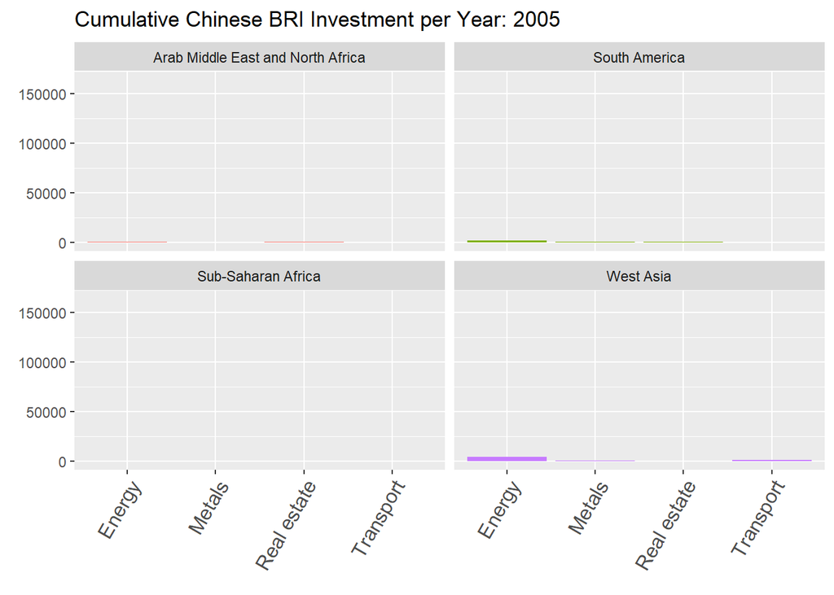

## Graph #2: GDP and BRI Investment

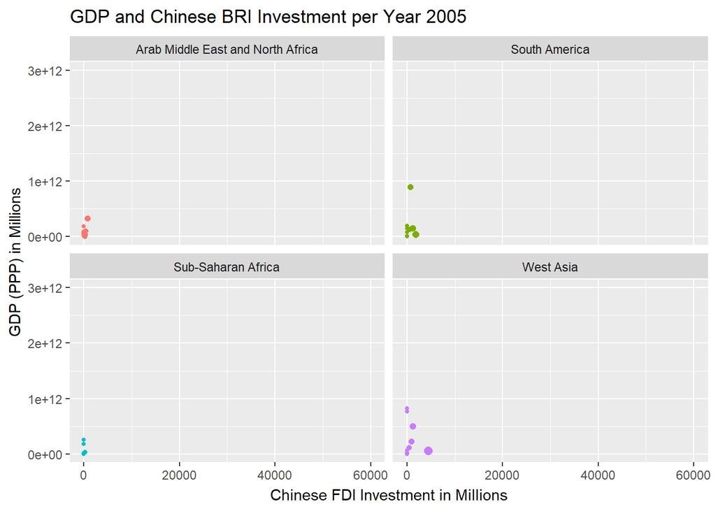